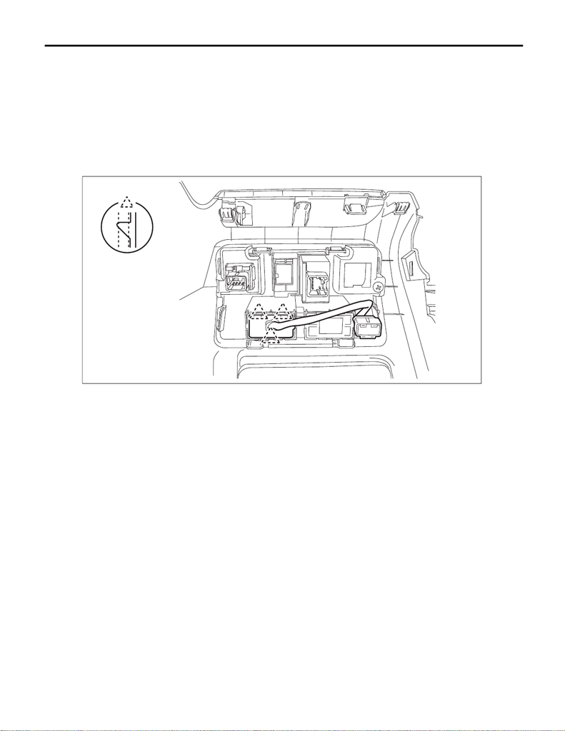

VDC-36

VDC OFF Switch

VEHICLE DYNAMICS CONTROL (VDC)

13.VDC OFF Switch

A: REMOVAL

NOTE:

For models other than STI model, disconnect the ground terminal from battery sensor.

2) Remove the cover assembly - instrument panel LWR driver OUT. <Ref. to EI-61, REMOVAL, Instrument

Panel Lower Cover.>

3) Release the claws and remove the VDC OFF switch.

B: INSTALLATION

1) Install the VDC OFF switch.

2) Install the cover assembly - instrument panel LWR driver OUT.

3) Connect the battery ground terminal. <Ref. to NT-5, BATTERY, NOTE, Note.>

NOTE:

For models other than STI model, connect the ground terminal to battery sensor.

VDC01294

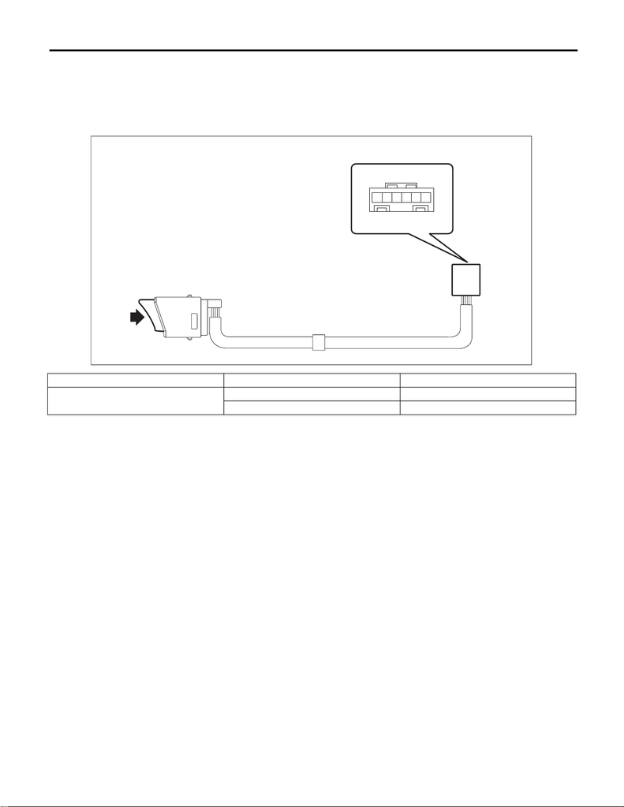

VDC-37

VDC OFF Switch

VEHICLE DYNAMICS CONTROL (VDC)

C: INSPECTION

1) Remove the VDC OFF switch. <Ref. to VDC-36, REMOVAL, VDC OFF Switch.>

2) Measure the resistance between the VDC OFF switch terminals.

Preparation tool:

Circuit tester

NOTE:

Replace the VDC OFF switch if the inspection result is not within the standard value.

Terminal No. Inspection conditions Standard

2 — 1

Switch OFF 1 MΩ or more

Switch ON Less than 1 Ω

VDC01296

2

1

[figure not shown]

VDC-38

VDC OFF Switch

VEHICLE DYNAMICS CONTROL (VDC)

[figure not shown]

VEHICLE DYNAMICS CONTROL (VDC)

(DIAGNOSTICS)

VDC(diag)

Page

2. Check List for Interview ..............................................................................4

3. General Description ...................................................................................8

4. Electrical Component Location ................................................................10

5. Control Module I/O Signal ........................................................................12

6. Subaru Select Monitor ..............................................................................15

7. Read Diagnostic Trouble Code (DTC) .....................................................21

8. Inspection Mode .......................................................................................22

9. Clear Memory Mode .................................................................................23

10. Warning Light Illumination Pattern ...........................................................24

11. List of Diagnostic Trouble Code (DTC) ....................................................42

12. Diagnostic Procedure with Diagnostic Trouble Code (DTC) ....................45

13. General Diagnostic Table .........................................................................83